# COMPSCIX 415.2 Homework 7

Jennifer Lu

7/22/2018

```r
library(tidyverse)
library(broom)
```

## Exercise 1

Load the train.csv dataset into R. How many observations and columns are there?

```r
train_from_csv <- read_csv('train.csv')
glimpse(train_from_csv)
```

```
## Observations: 1,460
## Variables: 81
## $ Id            <int> 1, 2, 3, 4, 5, 6, 7, 8, 9, 10, 11, 12, 13, 14, 1...
## $ MSSubClass    <int> 60, 20, 60, 70, 60, 50, 20, 60, 50, 190, 20, 60,...
## $ MSZoning      <chr> "RL", "RL", "RL", "RL", "RL", "RL", "RL", "RL", ...
## $ LotFrontage   <int> 65, 80, 68, 60, 84, 85, 75, NA, 51, 50, 70, 85, ...
## $ LotArea       <int> 8450, 9600, 11250, 9550, 14260, 14115, 10084, 10...
## $ Street        <chr> "Pave", "Pave", "Pave", "Pave", "Pave", "Pave", ...
## $ Alley         <chr> NA, NA, NA, NA, NA, NA, NA, NA, NA, NA, NA, NA, ...
## $ LotShape      <chr> "Reg", "Reg", "IR1", "IR1", "IR1", "IR1", "Reg",...
## $ LandContour   <chr> "Lvl", "Lvl", "Lvl", "Lvl", "Lvl", "Lvl", "Lvl",...
## $ Utilities     <chr> "AllPub", "AllPub", "AllPub", "AllPub", "AllPub"...
## $ LotConfig     <chr> "Inside", "FR2", "Inside", "Corner", "FR2", "Ins...
## $ LandSlope     <chr> "Gtl", "Gtl", "Gtl", "Gtl", "Gtl", "Gtl", "Gtl",...
## $ Neighborhood  <chr> "CollgCr", "Veenker", "CollgCr", "Crawfor", "NoR...
```

[output cut: 68 more lines]

There are 1,460 observations and 81 columns.

## Exercise 2

Normally at this point you would spend a few days on EDA, but for this homework we will do some very basic EDA and get right to fitting some linear regression models.

Our target will be SalePrice.

- Visualize the distribution of SalePrice.

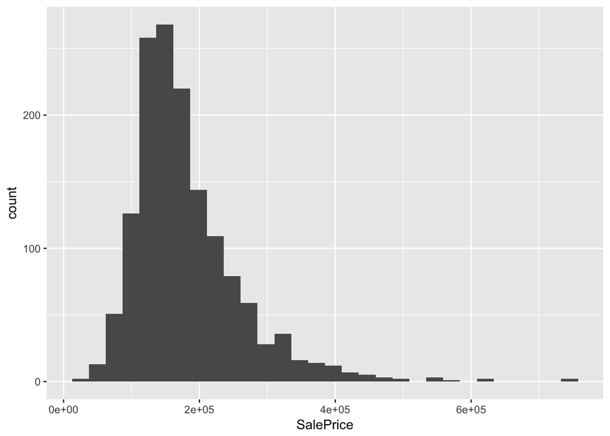

```r
ggplot(data = train_from_csv) +
  geom_histogram(mapping = aes(x=SalePrice))
```

- Visualize the covariation between SalePrice and Neighborhood.

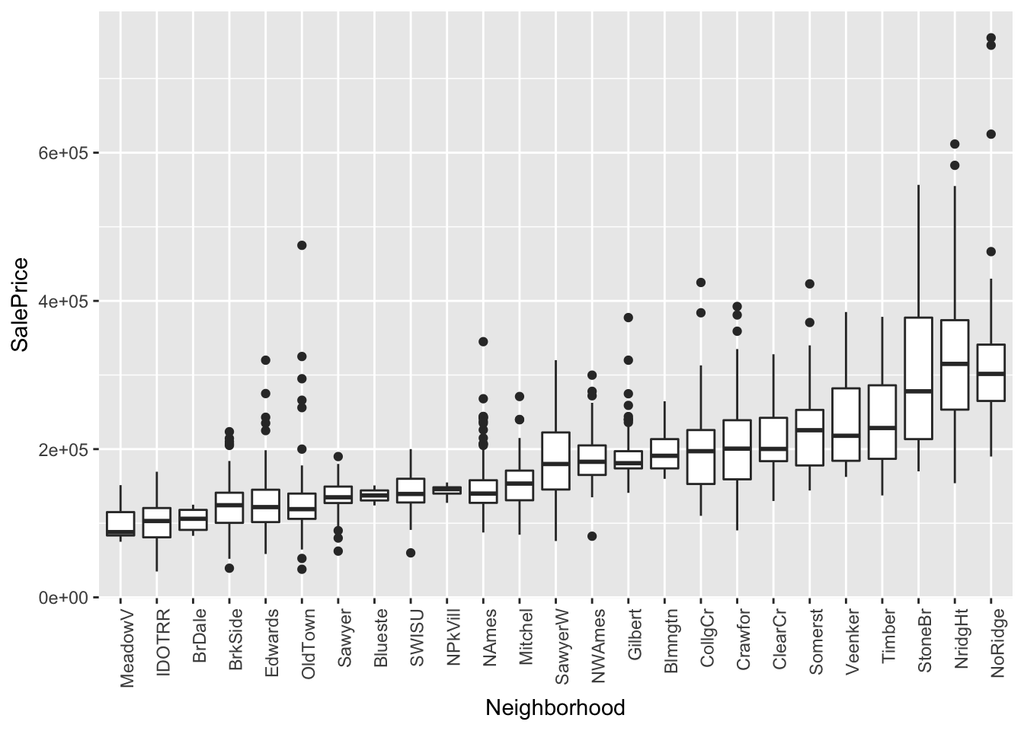

```r
ggplot(data = train_from_csv) +
  geom_boxplot(mapping = aes(x=reorder(Neighborhood, SalePrice, mean), y=SalePrice)) +
  theme(axis.text.x = element_text(angle = 90, hjust = 1)) +
  xlab("Neighborhood")
```

- Visualize the covariation between SalePrice and OverallQual.

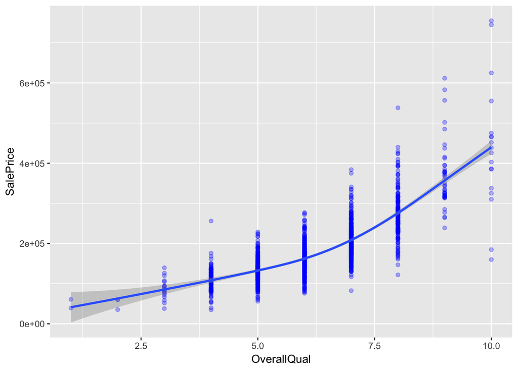

```r
ggplot(data = train_from_csv, mapping = aes(x=OverallQual, y=SalePrice)) +
  geom_point(alpha=0.3, color="blue") +
  geom_smooth()
```

## Exercise 3

Our target is called SalePrice. First, we can fit a simple regression model consisting of only the intercept (the average of SalePrice). Fit the model and then use the broom package to

```r
saleprice_lm <- lm(formula = SalePrice ~ 1, data = train_from_csv)
saleprice_lm
```

```
##
## Call:
## lm(formula = SalePrice ~ 1, data = train_from_csv)
##
## Coefficients:
## (Intercept)
##      180921
```

- take a look at the coefficient,

```r
tidy(saleprice_lm)
```

| term | estimate | std.error | statistic | p.value |
| --- | --- | --- | --- | --- |
| (Intercept) | 180921.2 | 2079.105 | 87.01877 | 0 |

- compare the coefficient to the average value of SalePrice, and

Error is pretty high.

- take a look at the R-squared.

```r
glance(saleprice_lm)
```

| r.squared | adj.r.squared | sigma | statistic | p.value | df | logLik | AIC | BIC | deviance | df.residual |
| --- | --- | --- | --- | --- | --- | --- | --- | --- | --- | --- |
| 0 | 0 | 79442.5 | NA | NA | 1 | -18544.02 | 37092.04 | 37102.62 | 9.207911e+12 | 1459 |

R-squared is zero because we’re looking at a constant mean.

## Exercise 4

Now fit a linear regression model using GrLivArea, OverallQual, and Neighborhood as the features. Don’t forget to look at data_description.txt to understand what these variables mean. Ask yourself these questions before fitting the model:

```r
area_lm <- lm(formula = SalePrice ~ GrLivArea, data = train_from_csv)
tidy(area_lm)
```

| term | estimate | std.error | statistic | p.value |
| --- | --- | --- | --- | --- |
| (Intercept) | 18569.0259 | 4480.754549 | 4.144174 | 3.606554e-05 |
| GrLivArea | 107.1304 | 2.793621 | 38.348207 | 4.518034e-223 |

```r
qual_lm <- lm(formula = SalePrice ~ OverallQual, data = train_from_csv)
tidy(qual_lm)
```

| term | estimate | std.error | statistic | p.value |
| --- | --- | --- | --- | --- |
| (Intercept) | -96206.08 | 5756.4074 | -16.71287 | 1.667971e-57 |
| OverallQual | 45435.80 | 920.4302 | 49.36366 | 2.185675e-313 |

```r
neighborhood_lm <- lm(formula = SalePrice ~ Neighborhood, data = train_from_csv)
tidy(neighborhood_lm)
```

| term | estimate | std.error | statistic | p.value |
| --- | --- | --- | --- | --- |
| (Intercept) | 194870.882 | 13096.68 | 14.8794092 | 1.120183e-46 |
| NeighborhoodBlueste | -57370.882 | 40366.68 | -1.4212434 | 1.554633e-01 |
| NeighborhoodBrDale | -90377.132 | 18808.68 | -4.8050766 | 1.709171e-06 |
| NeighborhoodBrkSide | -70036.831 | 14892.85 | -4.7027142 | 2.814264e-06 |
| NeighborhoodClearCr | 17694.546 | 16603.07 | 1.0657392 | 2.867208e-01 |
| NeighborhoodCollgCr | 3094.891 | 13818.91 | 0.2239605 | 8.228199e-01 |
| NeighborhoodCrawfor | 15753.843 | 15122.75 | 1.0417317 | 2.977116e-01 |
| NeighborhoodEdwards | -66651.182 | 14166.23 | -4.7049354 | 2.784258e-06 |
| NeighborhoodGilbert | -2016.376 | 14437.21 | -0.1396652 | 8.889441e-01 |
| NeighborhoodIDOTRR | -94747.099 | 15821.85 | -5.9883701 | 2.674531e-09 |

[output cut: 15 more lines]

- What kind of relationship will these features have with our target? They will have a linear relationship
- Can the relationship be estimated linearly? Yes.
- Are these good features, given the problem we are trying to solve? Yes.
- After fitting the model, output the coefficients and the R-squared using the broom package.

```r
glance(area_lm)
```

| r.squared | adj.r.squared | sigma | statistic | p.value | df | logLik | AIC | BIC | deviance | df.residual |
| --- | --- | --- | --- | --- | --- | --- | --- | --- | --- | --- |
| 0.5021487 | 0.5018072 | 56072.72 | 1470.585 | 4.518034e-223 | 2 | -18034.88 | 36075.76 | 36091.62 | 4.584171e+12 | 1458 |

```r
glance(qual_lm)
```

| r.squared | adj.r.squared | sigma | statistic | p.value | df | logLik | AIC | BIC | deviance | df.residual |
| --- | --- | --- | --- | --- | --- | --- | --- | --- | --- | --- |
| 0.6256519 | 0.6253951 | 48622.76 | 2436.771 | 2.185675e-313 | 2 | -17826.75 | 35659.49 | 35675.35 | 3.446964e+12 | 1458 |

```r
glance(neighborhood_lm)
```

| r.squared | adj.r.squared | sigma | statistic | p.value | df | logLik | AIC | BIC | deviance | df.residual |
| --- | --- | --- | --- | --- | --- | --- | --- | --- | --- | --- |
| 0.545575 | 0.5379749 | 53999 | 71.78487 | 1.5586e-225 | 25 | -17968.25 | 35988.51 | 36125.95 | 4.184305e+12 | 1435 |

Answer these questions:

- How would you interpret the coefficients on GrLivArea and OverallQual? There is a positive linear corrolation between GrLivArea and SalePrice, and OverallQual and SalePrice. Although, SalePrice is much more sensitive to changes in OverallQual than GrLivArea.
- How would you interpret the coefficient on NeighborhoodBrkSide? Different neighborhoods have different cost.
- Are the features significant?

- Are the features practically significant?

Yes, bigger houses cost more and better quality houses cost more.

- Is the model a good fit? Yes.

## Exercise 5 (OPTIONAL - won’t be graded)

Feel free to play around with linear regression. Add some other features and see how the model results change.

## Exercise 6

One downside of the linear model is that it is sensitive to unusual values because the distance incorporates a squared term. Fit a linear model to the simulated data below (use y as the target and x as the feature), and look at the resulting coefficients and R-squared. Rerun it about 5-6 times to generate different simulated datasets. What do you notice about the model’s coefficient on x and the R-squared values?

There is a ton of variability among the coefficient on x and the R-squared values.

```r
sim1a <- tibble(
  x = rep(1:10, each = 3),
  y = x * 1.5 + 6 + rt(length(x), df = 2)
)
sim1a_lm <- lm(formula = y ~ x, data = sim1a)
tidy(sim1a_lm)
```

| term | estimate | std.error | statistic | p.value |
| --- | --- | --- | --- | --- |
| (Intercept) | 5.568321 | 0.53332686 | 10.44073 | 3.683103e-11 |
| x | 1.517393 | 0.08595341 | 17.65366 | 1.041385e-16 |

```r
glance(sim1a_lm)
```

| r.squared | adj.r.squared | sigma | statistic | p.value | df | logLik | AIC | BIC | deviance | df.residual |
| --- | --- | --- | --- | --- | --- | --- | --- | --- | --- | --- |
| 0.9175626 | 0.9146185 | 1.35223 | 311.6519 | 1.041385e-16 | 2 | -50.58592 | 107.1718 | 111.3754 | 51.19876 | 28 |

```r
sim2a <- tibble(
  x = rep(1:10, each = 3),
  y = x * 1.5 + 6 + rt(length(x), df = 2)
)
sim2a_lm <- lm(formula = y ~ x, data = sim2a)
tidy(sim2a_lm)
```

| term | estimate | std.error | statistic | p.value |
| --- | --- | --- | --- | --- |
| (Intercept) | 7.228689 | 0.738959 | 9.78226 | 1.561250e-10 |
| x | 1.321329 | 0.119094 | 11.09484 | 9.256416e-12 |

```r
glance(sim2a_lm)
```

| r.squared | adj.r.squared | sigma | statistic | p.value | df | logLik | AIC | BIC | deviance | df.residual |
| --- | --- | --- | --- | --- | --- | --- | --- | --- | --- | --- |
| 0.8146867 | 0.8080684 | 1.873603 | 123.0955 | 9.256416e-12 | 2 | -60.36916 | 126.7383 | 130.9419 | 98.29086 | 28 |

```r
sim3a <- tibble(
  x = rep(1:10, each = 3),
  y = x * 1.5 + 6 + rt(length(x), df = 2)
)
sim3a_lm <- lm(formula = y ~ x, data = sim3a)
tidy(sim3a_lm)
```

| term | estimate | std.error | statistic | p.value |
| --- | --- | --- | --- | --- |
| (Intercept) | 8.005978 | 1.1301980 | 7.083696 | 1.047090e-07 |
| x | 1.156671 | 0.1821479 | 6.350176 | 7.170459e-07 |

```r
glance(sim3a_lm)
```

| r.squared | adj.r.squared | sigma | statistic | p.value | df | logLik | AIC | BIC | deviance | df.residual |
| --- | --- | --- | --- | --- | --- | --- | --- | --- | --- | --- |
| 0.5901924 | 0.5755564 | 2.865575 | 40.32474 | 7.170459e-07 | 2 | -73.11633 | 152.2327 | 156.4363 | 229.9225 | 28 |

```r
sim4a <- tibble(
  x = rep(1:10, each = 3),
  y = x * 1.5 + 6 + rt(length(x), df = 2)
)
sim4a_lm <- lm(formula = y ~ x, data = sim4a)
tidy(sim4a_lm)
```

| term | estimate | std.error | statistic | p.value |
| --- | --- | --- | --- | --- |
| (Intercept) | 7.394830 | 2.0394388 | 3.625914 | 0.0011344882 |
| x | 1.441691 | 0.3286853 | 4.386236 | 0.0001480624 |

```r
glance(sim4a_lm)
```

| r.squared | adj.r.squared | sigma | statistic | p.value | df | logLik | AIC | BIC | deviance | df.residual |
| --- | --- | --- | --- | --- | --- | --- | --- | --- | --- | --- |
| 0.4072703 | 0.3861014 | 5.170921 | 19.23907 | 0.0001480624 | 2 | -90.82479 | 187.6496 | 191.8532 | 748.6759 | 28 |

```r
sim5a <- tibble(
  x = rep(1:10, each = 3),
  y = x * 1.5 + 6 + rt(length(x), df = 2)
)
sim5a_lm <- lm(formula = y ~ x, data = sim5a)
tidy(sim5a_lm)
```

| term | estimate | std.error | statistic | p.value |
| --- | --- | --- | --- | --- |
| (Intercept) | 5.447360 | 0.47243289 | 11.53044 | 3.797368e-12 |
| x | 1.669526 | 0.07613945 | 21.92721 | 3.584740e-19 |

```r
glance(sim5a_lm)
```

| r.squared | adj.r.squared | sigma | statistic | p.value | df | logLik | AIC | BIC | deviance | df.residual |
| --- | --- | --- | --- | --- | --- | --- | --- | --- | --- | --- |
| 0.9449688 | 0.9430034 | 1.197836 | 480.8026 | 3.58474e-19 | 2 | -46.94876 | 99.89752 | 104.1011 | 40.17471 | 28 |

```r
sim6a <- tibble(
  x = rep(1:10, each = 3),
  y = x * 1.5 + 6 + rt(length(x), df = 2)
)
sim6a_lm <- lm(formula = y ~ x, data = sim6a)
tidy(sim6a_lm)
```

| term | estimate | std.error | statistic | p.value |
| --- | --- | --- | --- | --- |
| (Intercept) | 5.266829 | 1.1034276 | 4.773153 | 5.156412e-05 |
| x | 1.614821 | 0.1778335 | 9.080525 | 7.739990e-10 |

```r
glance(sim6a_lm)
```

| r.squared | adj.r.squared | sigma | statistic | p.value | df | logLik | AIC | BIC | deviance | df.residual |
| --- | --- | --- | --- | --- | --- | --- | --- | --- | --- | --- |
| 0.7465052 | 0.7374519 | 2.7977 | 82.45594 | 7.73999e-10 | 2 | -72.39719 | 150.7944 | 154.998 | 219.1595 | 28 |